# Caracterização do desenvolvimento de bibliotecas multiplataforma

#### Análise temporal com janela deslizante

#### Janela de 24 semanas

#### QP2.1 - A equipe de desenvolvimento de bibliotecas multiplataforma tende a tornar-se mais generalista ou especialista ao longo do tempo?

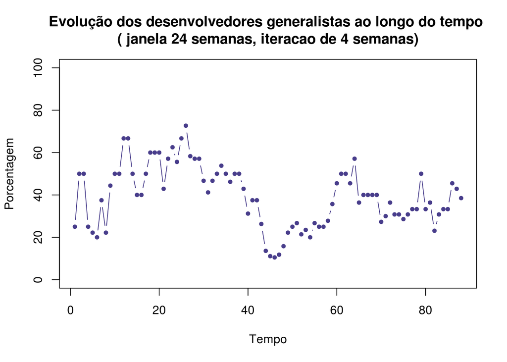

```
KPSS Test for Level Stationarity
```

data: dev_all_time24_2$porcentage KPSS Level = 0.65129, Truncation lag parameter = 2, p-value = 0.01797

```
KPSS Test for Trend Stationarity
```

data: dev_all_time24_2$porcentage KPSS Trend = 0.19798, Truncation lag parameter = 2, p-value = 0.01676

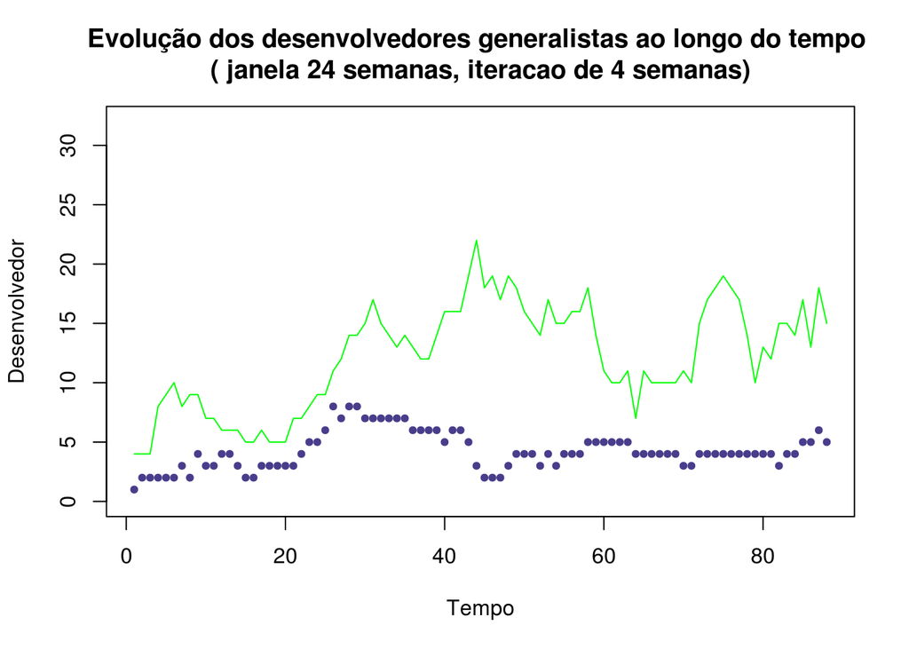

```
KPSS Test for Level Stationarity
```

data: dev_all_time24_2$n KPSS Level = 0.32918, Truncation lag parameter = 2, p-value = 0.1

```
KPSS Test for Trend Stationarity
```

data: dev_all_time24_2$n KPSS Trend = 0.31048, Truncation lag parameter = 2, p-value = 0.01

#### QP2.2 - Dos desenvolvedores generalistas, eles tendem a trabalhar com mais plataformas ao longo do tempo?

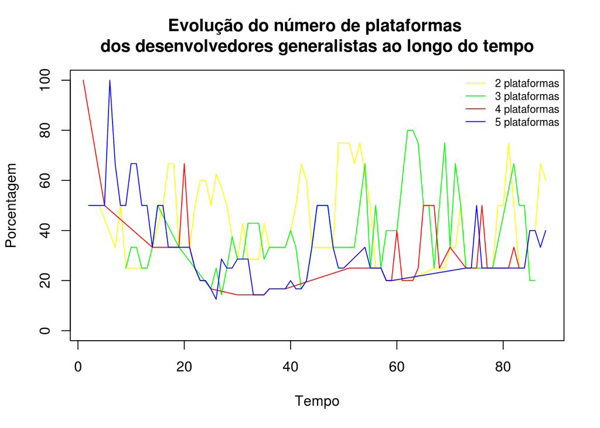

#### 2

```
KPSS Test for Level Stationarity
```

data: dev_gen_time24_2$porcentage KPSS Level = 0.23508, Truncation lag parameter = 1, p-value = 0.1

```
KPSS Test for Trend Stationarity
```

data: dev_gen_time24_2$porcentage KPSS Trend = 0.096555, Truncation lag parameter = 1, p-value = 0.1

#### 3

```
KPSS Test for Level Stationarity
```

data: dev_gen_time24_3$porcentage KPSS Level = 0.71161, Truncation lag parameter = 1, p-value = 0.01249

```
KPSS Test for Trend Stationarity
```

data: dev_gen_time24_3$porcentage KPSS Trend = 0.13963, Truncation lag parameter = 1, p-value = 0.06179

#### 4

```
KPSS Test for Level Stationarity
```

data: dev_gen_time24_4$porcentage KPSS Level = 0.2628, Truncation lag parameter = 1, p-value = 0.1

```
KPSS Test for Trend Stationarity
```

data: dev_gen_time24_4$porcentage KPSS Trend = 0.2479, Truncation lag parameter = 1, p-value = 0.01

#### 5

```
KPSS Test for Level Stationarity
```

data: dev_gen_time24_5$porcentage KPSS Level = 1.0133, Truncation lag parameter = 1, p-value = 0.01

```
KPSS Test for Trend Stationarity
```

data: dev_gen_time24_5$porcentage KPSS Trend = 0.44432, Truncation lag parameter = 1, p-value = 0.01

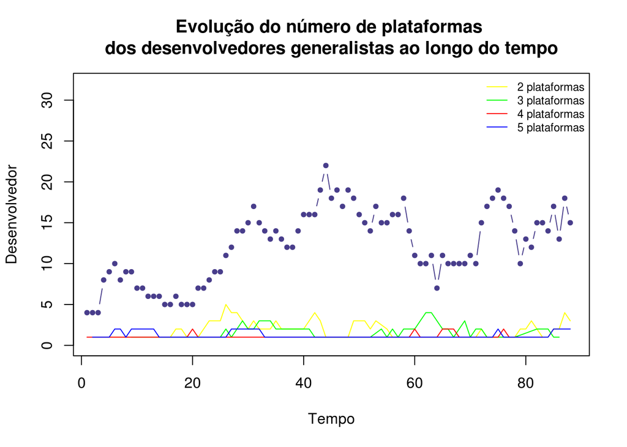

#### 2

```
KPSS Test for Level Stationarity
```

data: dev_gen_time24_2$n KPSS Level = 0.33587, Truncation lag parameter = 1, p-value = 0.1

```
KPSS Test for Trend Stationarity
```

data: dev_gen_time24_2$n KPSS Trend = 0.29012, Truncation lag parameter = 1, p-value = 0.01

#### 3

```
KPSS Test for Level Stationarity
```

data: dev_gen_time24_3$n KPSS Level = 0.19409, Truncation lag parameter = 1, p-value = 0.1

```
KPSS Test for Trend Stationarity
```

data: dev_gen_time24_3$n KPSS Trend = 0.15138, Truncation lag parameter = 1, p-value = 0.04552

#### 4

```
KPSS Test for Level Stationarity
```

data: dev_gen_time24_4$n KPSS Level = 0.17144, Truncation lag parameter = 1, p-value = 0.1

```
KPSS Test for Trend Stationarity
```

data: dev_gen_time24_4$n KPSS Trend = 0.095765, Truncation lag parameter = 1, p-value = 0.1

#### 5

```
KPSS Test for Level Stationarity
```

data: dev_gen_time24_5$n KPSS Level = 0.27243, Truncation lag parameter = 1, p-value = 0.1

```
KPSS Test for Trend Stationarity
```

data: dev_gen_time24_5$n KPSS Trend = 0.16159, Truncation lag parameter = 1, p-value = 0.03701

#### QP3.1 - Os desenvolvedores de bibliotecas multiplataforma tendem a especializar-se em dispositivos desktop ou mobile ao longo do tempo?

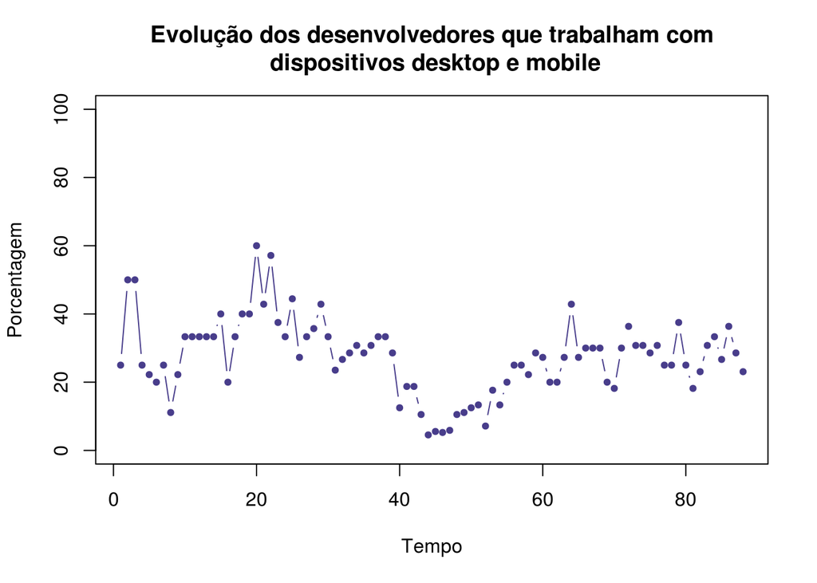

```
KPSS Test for Level Stationarity
```

data: devicetype_time24_2$porcentage KPSS Level = 0.511, Truncation lag parameter = 2, p-value = 0.03919

```
KPSS Test for Trend Stationarity
```

data: devicetype_time24_2$porcentage KPSS Trend = 0.27949, Truncation lag parameter = 2, p-value = 0.01

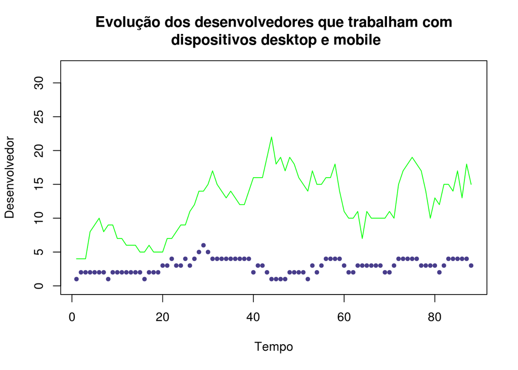

```
KPSS Test for Level Stationarity
```

data: devicetype_time24_2$developer KPSS Level = 0.41096, Truncation lag parameter = 2, p-value = 0.07243

```
KPSS Test for Trend Stationarity
```

data: devicetype_time24_2$developer KPSS Trend = 0.17357, Truncation lag parameter = 2, p-value = 0.02702

#### Rastreamento dos desenvolvedores

Selecionamos os desenvolvedores que comitaram nas primeiras 24 semanas do periodo de análise e verificamos o numero de plataformas que eles fizeram trabalharam em cada janela de tempo

As plataformas consideradas foram: win, iphone, linux, macos, e android

Filtrei alguns desenvolvedores com poucos commits pq o plot.ts so aceita matriz de ate 10 colunas

[figure not shown]

## ————————————————————————-